# Classification

##### Up-Sampled Train Set

```r
up_nb_clf <- train_model("naive_bayes", up_train_set)
```

```
Naive Bayes

880 samples
 32 predictor
  2 classes: 'fail', 'pass'

Pre-processing: centered (72), scaled (72)
Resampling: Cross-Validated (10 fold, repeated 10 times)
Summary of sample sizes: 792, 792, 792, 792, 792, 792, ...
Resampling results across tuning parameters:

  usekernel  Accuracy   Kappa
  FALSE      0.8334091  0.666818182
   TRUE      0.5044318  0.008863636

Tuning parameter 'laplace' was held constant at a value of 0
Tuning
 parameter 'adjust' was held constant at a value of 1
Accuracy was used to select the optimal model using the largest value.
The final values used for the model were laplace = 0, usekernel = FALSE
 and adjust = 1.
```

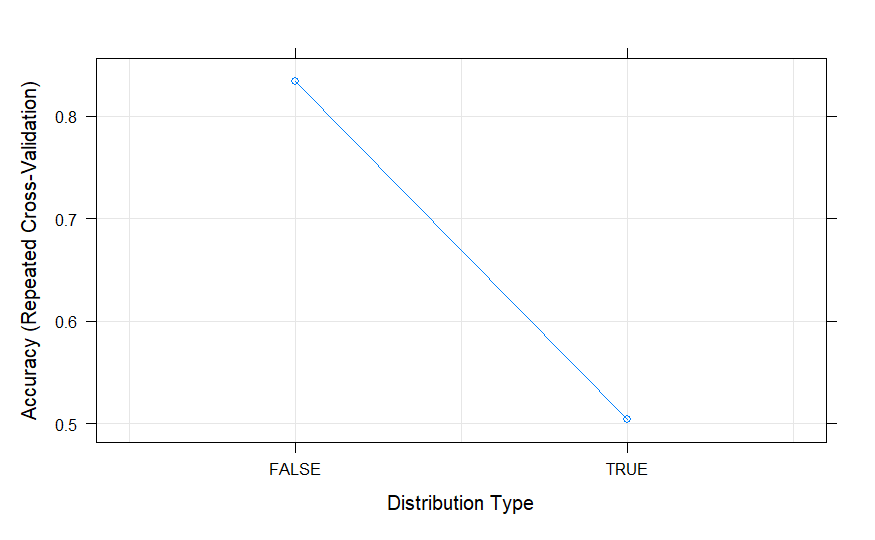

```r
plot(up_nb_clf)
```

Perform hyperparameter tuning using `tuneGrid`.

```r
up_nb_tuneGrid <- expand.grid(
  adjust = 1,
  usekernel = FALSE,
  laplace = seq(0, 1, 0.1)
)

up_nb_clf <- train_model("naive_bayes", up_train_set, tuneGrid = up_nb_tuneGrid)
```

```
Naive Bayes

880 samples
 32 predictor
  2 classes: 'fail', 'pass'

Pre-processing: centered (72), scaled (72)
Resampling: Cross-Validated (10 fold, repeated 10 times)
Summary of sample sizes: 792, 792, 792, 792, 792, 792, ...
Resampling results across tuning parameters:

  laplace  Accuracy   Kappa
  0.0      0.8334091  0.6668182
  0.1      0.8334091  0.6668182
  0.2      0.8334091  0.6668182
  0.3      0.8334091  0.6668182
  0.4      0.8334091  0.6668182
  0.5      0.8334091  0.6668182
  0.6      0.8334091  0.6668182
  0.7      0.8334091  0.6668182
  0.8      0.8334091  0.6668182
  0.9      0.8334091  0.6668182
  1.0      0.8334091  0.6668182

Tuning parameter 'usekernel' was held constant at a value of FALSE

Tuning parameter 'adjust' was held constant at a value of 1
Accuracy was used to select the optimal model using the largest value.
The final values used for the model were laplace = 0, usekernel = FALSE
 and adjust = 1.
```

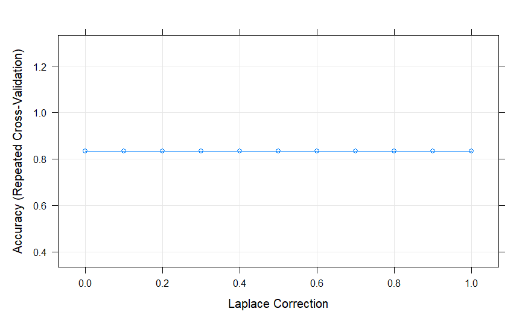

```r
plot(up_nb_clf)
```

Tuning done.

```r
up_nb_metrics <- evaluate_model(up_nb_clf, "NB")
```

```
Confusion Matrix and Statistics

          Reference
Prediction fail pass
      fail   16   21
      pass    4   88

               Accuracy : 0.8062
                 95% CI : (0.7274, 0.8705)
    No Information Rate : 0.845
    P-Value [Acc > NIR] : 0.906524

                  Kappa : 0.4509

 Mcnemar's Test P-Value : 0.001374

              Precision : 0.4324
                 Recall : 0.8000
                     F1 : 0.5614
             Prevalence : 0.1550
         Detection Rate : 0.1240
   Detection Prevalence : 0.2868
      Balanced Accuracy : 0.8037

       'Positive' Class : fail
```

#### AdaBoost

##### Original Train Set

```r
ab_clf <- train_model("adaboost")
```

```
AdaBoost Classification Trees

520 samples
 32 predictor
  2 classes: 'fail', 'pass'

Pre-processing: centered (72), scaled (72)
Resampling: Cross-Validated (10 fold, repeated 10 times)
Summary of sample sizes: 468, 468, 468, 468, 468, 468, ...
Resampling results across tuning parameters:

  nIter  method         Accuracy   Kappa
   50    Adaboost.M1    0.9273077  0.6952813
   50    Real adaboost  0.9267308  0.6615599
  100    Adaboost.M1    0.9273077  0.6915609
  100    Real adaboost  0.9319231  0.6849066
  150    Adaboost.M1    0.9284615  0.6949823
  150    Real adaboost  0.9342308  0.6966327

Accuracy was used to select the optimal model using the largest value.
The final values used for the model were nIter = 150 and method = Real adaboost.
```

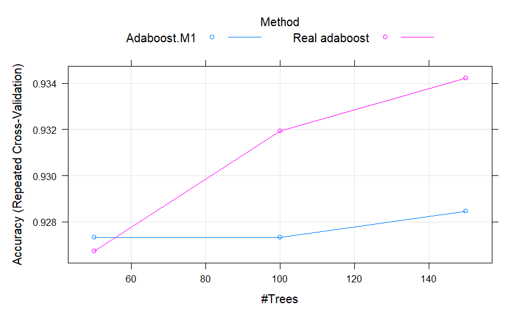

```r
plot(ab_clf)
```

Perform hyperparameter tuning using `tuneGrid`.

```r
ab_tuneGrid <- expand.grid(
  method = "Real adaboost",
  nIter = seq(150, 500, 50)
)

ab_clf <- train_model("adaboost", tuneGrid = ab_tuneGrid)
```

```
AdaBoost Classification Trees

520 samples
 32 predictor
  2 classes: 'fail', 'pass'

Pre-processing: centered (72), scaled (72)
Resampling: Cross-Validated (10 fold, repeated 10 times)
Summary of sample sizes: 468, 468, 468, 468, 468, 468, ...
Resampling results across tuning parameters:

  nIter  Accuracy   Kappa
  150    0.9342308  0.6966327
  200    0.9344231  0.7002634
  250    0.9350000  0.7032652
  300    0.9361538  0.7072723
  350    0.9355769  0.7052545
  400    0.9361538  0.7076341
  450    0.9361538  0.7069442
  500    0.9361538  0.7072199

Tuning parameter 'method' was held constant at a value of Real adaboost
Accuracy was used to select the optimal model using the largest value.
The final values used for the model were nIter = 300 and method = Real adaboost.
```

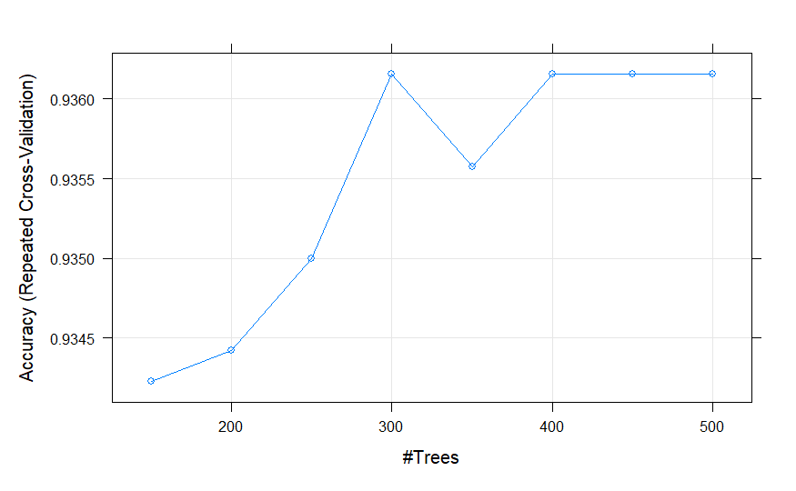

```r
plot(ab_clf)
```

Tuning done.

```r
ab_metrics <- evaluate_model(ab_clf, "AB")
```

```
Confusion Matrix and Statistics

          Reference
Prediction fail pass
      fail   13    3
      pass    7  106

               Accuracy : 0.9225
                 95% CI : (0.8621, 0.9622)
    No Information Rate : 0.845
    P-Value [Acc > NIR] : 0.006716

                  Kappa : 0.6778

 Mcnemar's Test P-Value : 0.342782

              Precision : 0.8125
                 Recall : 0.6500
                     F1 : 0.7222
             Prevalence : 0.1550
         Detection Rate : 0.1008
   Detection Prevalence : 0.1240
      Balanced Accuracy : 0.8112

       'Positive' Class : fail
```

##### Down-Sampled Train Set

```r
down_ab_clf <- train_model("adaboost", down_train_set)
```

```
AdaBoost Classification Trees

160 samples
 32 predictor
  2 classes: 'fail', 'pass'

Pre-processing: centered (72), scaled (72)
Resampling: Cross-Validated (10 fold, repeated 10 times)
Summary of sample sizes: 144, 144, 144, 144, 144, 144, ...
Resampling results across tuning parameters:

  nIter  method         Accuracy  Kappa
   50    Adaboost.M1    0.840625  0.68125
   50    Real adaboost  0.866875  0.73375
  100    Adaboost.M1    0.841250  0.68250
  100    Real adaboost  0.867500  0.73500
  150    Adaboost.M1    0.843125  0.68625
  150    Real adaboost  0.873750  0.74750

Accuracy was used to select the optimal model using the largest value.
The final values used for the model were nIter = 150 and method = Real adaboost.
```

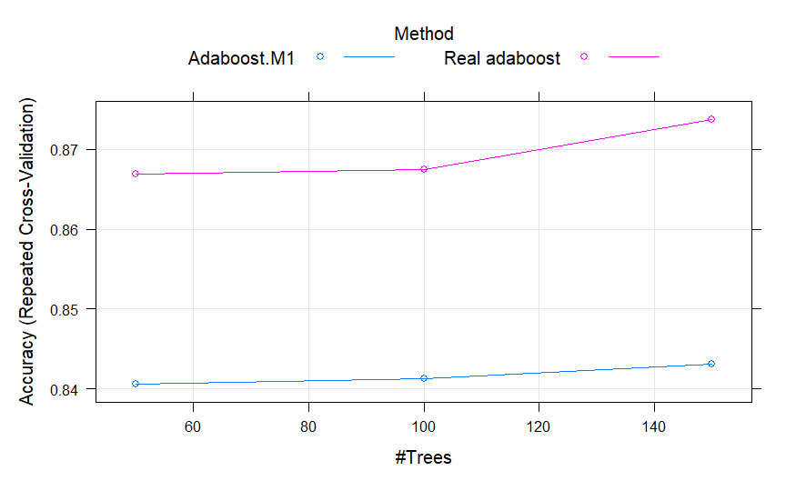

```r
plot(down_ab_clf)
```

Perform hyperparameter tuning using `tuneGrid`.

```r
down_ab_tuneGrid <- expand.grid(
  method = "Real adaboost",
  nIter = seq(150, 500, 50)
)

down_ab_clf <- train_model(
  "adaboost",
  down_train_set,
  tuneGrid = down_ab_tuneGrid
)
```

```
AdaBoost Classification Trees

160 samples
 32 predictor
  2 classes: 'fail', 'pass'

Pre-processing: centered (72), scaled (72)
Resampling: Cross-Validated (10 fold, repeated 10 times)
Summary of sample sizes: 144, 144, 144, 144, 144, 144, ...
Resampling results across tuning parameters:

  nIter  Accuracy  Kappa
  150    0.873750  0.74750
  200    0.876250  0.75250
  250    0.879375  0.75875
  300    0.878750  0.75750
  350    0.878125  0.75625
  400    0.880000  0.76000
  450    0.880625  0.76125
  500    0.880000  0.76000

Tuning parameter 'method' was held constant at a value of Real adaboost
Accuracy was used to select the optimal model using the largest value.
The final values used for the model were nIter = 450 and method = Real adaboost.
```

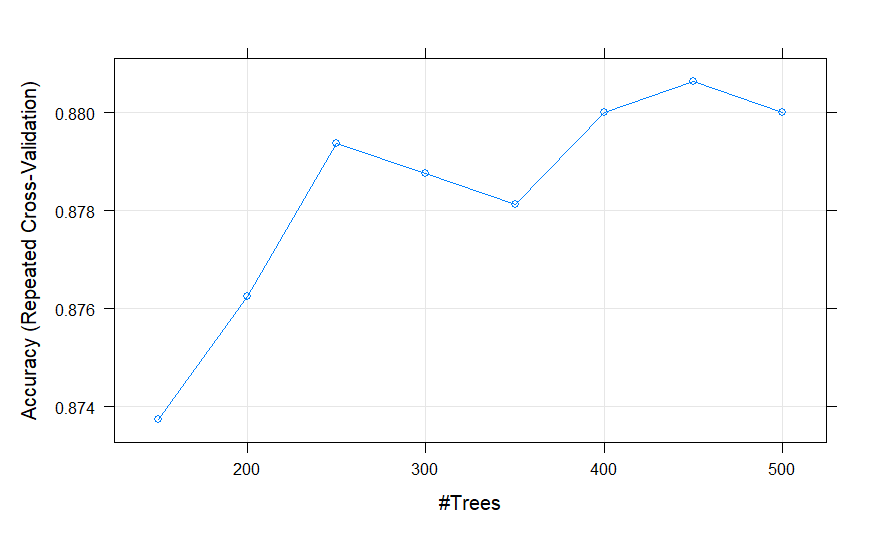

```r
plot(down_ab_clf)
```

Tuning done.

```r
down_ab_metrics <- evaluate_model(down_ab_clf, "AB")
```

```
Confusion Matrix and Statistics

          Reference
Prediction fail pass
      fail   17   11
      pass    3   98

               Accuracy : 0.8915
                 95% CI : (0.8246, 0.9394)
    No Information Rate : 0.845
    P-Value [Acc > NIR] : 0.08614

                  Kappa : 0.6439

 Mcnemar's Test P-Value : 0.06137

              Precision : 0.6071
                 Recall : 0.8500
                     F1 : 0.7083
             Prevalence : 0.1550
         Detection Rate : 0.1318
   Detection Prevalence : 0.2171
      Balanced Accuracy : 0.8745

       'Positive' Class : fail
```

##### Up-Sampled Train Set

```r
up_ab_clf <- train_model("adaboost", up_train_set)
```

```
AdaBoost Classification Trees

880 samples
 32 predictor
  2 classes: 'fail', 'pass'

Pre-processing: centered (72), scaled (72)
Resampling: Cross-Validated (10 fold, repeated 10 times)
Summary of sample sizes: 792, 792, 792, 792, 792, 792, ...
Resampling results across tuning parameters:

  nIter  method         Accuracy   Kappa
   50    Adaboost.M1    0.9814773  0.9629545
   50    Real adaboost  0.9869318  0.9738636
  100    Adaboost.M1    0.9836364  0.9672727
  100    Real adaboost  0.9884091  0.9768182
  150    Adaboost.M1    0.9842045  0.9684091
  150    Real adaboost  0.9886364  0.9772727

Accuracy was used to select the optimal model using the largest value.
The final values used for the model were nIter = 150 and method = Real adaboost.
```

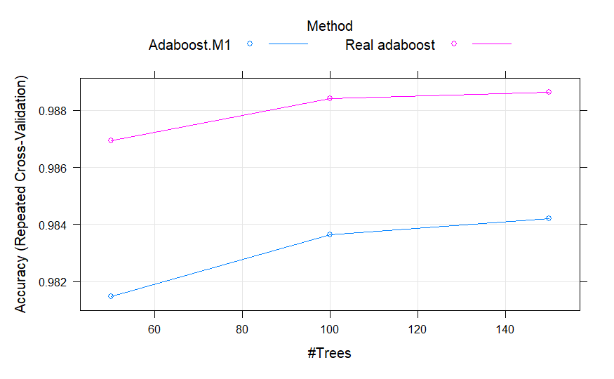

```r
plot(up_ab_clf)
```

Perform hyperparameter tuning using `tuneGrid`.

```r
up_ab_tuneGrid <- expand.grid(
  method = "Real adaboost",
  nIter = seq(150, 500, 50)
)

up_ab_clf <- train_model(
  "adaboost",
  up_train_set,
  tuneGrid = up_ab_tuneGrid
)
```

```
AdaBoost Classification Trees

880 samples
 32 predictor
  2 classes: 'fail', 'pass'

Pre-processing: centered (72), scaled (72)
Resampling: Cross-Validated (10 fold, repeated 10 times)
Summary of sample sizes: 792, 792, 792, 792, 792, 792, ...
Resampling results across tuning parameters:

  nIter  Accuracy   Kappa
  150    0.9886364  0.9772727
  200    0.9882955  0.9765909
  250    0.9890909  0.9781818
  300    0.9892045  0.9784091
  350    0.9885227  0.9770455
  400    0.9885227  0.9770455
  450    0.9888636  0.9777273
  500    0.9886364  0.9772727

Tuning parameter 'method' was held constant at a value of Real adaboost
Accuracy was used to select the optimal model using the largest value.
The final values used for the model were nIter = 300 and method = Real adaboost.
```

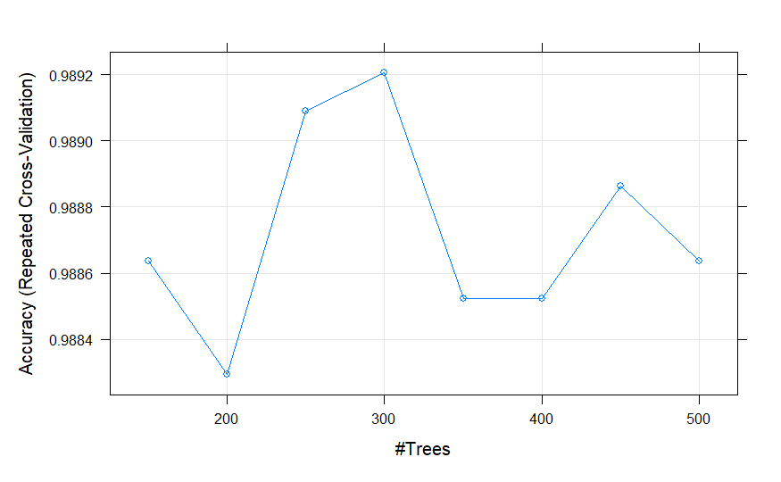

```r
plot(up_ab_clf)
```

Tuning done.

```r
up_ab_metrics <- evaluate_model(up_ab_clf, "AB")
```

```
Confusion Matrix and Statistics

          Reference
Prediction fail pass
      fail   13    4
      pass    7  105

               Accuracy : 0.9147
                 95% CI : (0.8525, 0.9567)
    No Information Rate : 0.845
    P-Value [Acc > NIR] : 0.01442

                  Kappa : 0.6533

 Mcnemar's Test P-Value : 0.54649

              Precision : 0.7647
                 Recall : 0.6500
                     F1 : 0.7027
             Prevalence : 0.1550
         Detection Rate : 0.1008
   Detection Prevalence : 0.1318
      Balanced Accuracy : 0.8067

       'Positive' Class : fail
```

#### XGBoost (Linear)

##### Original Train Set

```r
xgb_lin_clf <- train_model("xgbLinear")
```

```
eXtreme Gradient Boosting

520 samples
 32 predictor
  2 classes: 'fail', 'pass'

Pre-processing: centered (72), scaled (72)
Resampling: Cross-Validated (10 fold, repeated 10 times)
Summary of sample sizes: 468, 468, 468, 468, 468, 468, ...
Resampling results across tuning parameters:

  lambda  alpha  nrounds  Accuracy   Kappa
  0e+00   0e+00   50      0.9319231  0.7264795
  0e+00   0e+00  100      0.9338462  0.7353734
  0e+00   0e+00  150      0.9338462  0.7355818
  0e+00   1e-04   50      0.9315385  0.7245072
  0e+00   1e-04  100      0.9323077  0.7294429
  0e+00   1e-04  150      0.9315385  0.7262098
  0e+00   1e-01   50      0.9323077  0.7278901
  0e+00   1e-01  100      0.9307692  0.7240939
  0e+00   1e-01  150      0.9303846  0.7232999
  1e-04   0e+00   50      0.9315385  0.7241425
  1e-04   0e+00  100      0.9323077  0.7291221
  1e-04   0e+00  150      0.9319231  0.7274513
  1e-04   1e-04   50      0.9328846  0.7307211
  1e-04   1e-04  100      0.9325000  0.7305241
  1e-04   1e-04  150      0.9332692  0.7336950
  1e-04   1e-01   50      0.9325000  0.7289523
  1e-04   1e-01  100      0.9311538  0.7255712
  1e-04   1e-01  150      0.9307692  0.7247772
  1e-01   0e+00   50      0.9321154  0.7282950
  1e-01   0e+00  100      0.9326923  0.7322473
  1e-01   0e+00  150      0.9325000  0.7316936
  1e-01   1e-04   50      0.9321154  0.7282950
  1e-01   1e-04  100      0.9325000  0.7316164
  1e-01   1e-04  150      0.9328846  0.7334279
  1e-01   1e-01   50      0.9298077  0.7196352
  1e-01   1e-01  100      0.9311538  0.7276114
  1e-01   1e-01  150      0.9311538  0.7275523

Tuning parameter 'eta' was held constant at a value of 0.3
Accuracy was used to select the optimal model using the largest value.
The final values used for the model were nrounds = 100, lambda = 0, alpha = 0 and eta = 0.3.
```

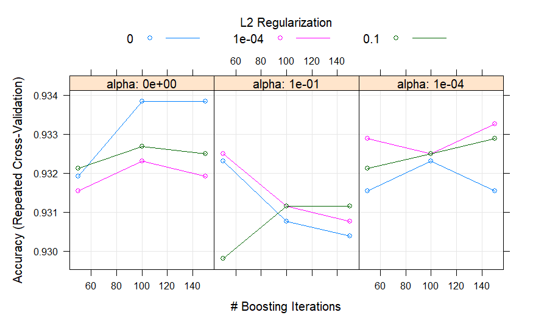

```r
plot(xgb_lin_clf)
```

Perform hyperparameter tuning using `tuneGrid`.

```r
xgb_lin_tuneGrid <- expand.grid(
  eta = 0.3,
  lambda = 0,
  alpha = 0,
  nrounds = seq(50, 100, 10)
)

xgb_lin_clf <- train_model("xgbLinear", tuneGrid = xgb_lin_tuneGrid)
```

```
eXtreme Gradient Boosting

520 samples
 32 predictor
  2 classes: 'fail', 'pass'

Pre-processing: centered (72), scaled (72)
Resampling: Cross-Validated (10 fold, repeated 10 times)
Summary of sample sizes: 468, 468, 468, 468, 468, 468, ...
Resampling results across tuning parameters:

  nrounds  Accuracy   Kappa
   50      0.9319231  0.7264795
   60      0.9313462  0.7248324
   70      0.9319231  0.7268958
   80      0.9321154  0.7269097
   90      0.9328846  0.7309063
  100      0.9338462  0.7353734

Tuning parameter 'lambda' was held constant at a value of 0
Tuning parameter 'alpha' was
 held constant at a value of 0
Tuning parameter 'eta' was held constant at a value of 0.3
Accuracy was used to select the optimal model using the largest value.
The final values used for the model were nrounds = 100, lambda = 0, alpha = 0 and eta = 0.3.
```

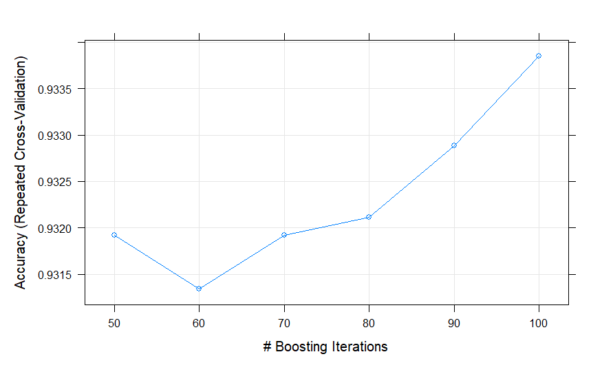

```r
plot(xgb_lin_clf)
```

Tuning done.

```r
xgb_lin_metrics <- evaluate_model(xgb_lin_clf, "XGB - Linear", "XGB")
```

```
Confusion Matrix and Statistics

          Reference
Prediction fail pass
      fail   14    5
      pass    6  104

               Accuracy : 0.9147
                 95% CI : (0.8525, 0.9567)
    No Information Rate : 0.845
    P-Value [Acc > NIR] : 0.01442

                  Kappa : 0.6678

 Mcnemar's Test P-Value : 1.00000

              Precision : 0.7368
                 Recall : 0.7000
                     F1 : 0.7179
             Prevalence : 0.1550
         Detection Rate : 0.1085
   Detection Prevalence : 0.1473
      Balanced Accuracy : 0.8271

       'Positive' Class : fail
```

##### Down-Sampled Train Set

```r
down_xgb_lin_clf <- train_model("xgbLinear", down_train_set)
```

```
eXtreme Gradient Boosting

160 samples
 32 predictor
  2 classes: 'fail', 'pass'

Pre-processing: centered (72), scaled (72)
Resampling: Cross-Validated (10 fold, repeated 10 times)
Summary of sample sizes: 144, 144, 144, 144, 144, 144, ...
Resampling results across tuning parameters:

  lambda  alpha  nrounds  Accuracy  Kappa
  0e+00   0e+00   50      0.847500  0.69500
  0e+00   0e+00  100      0.850000  0.70000
  0e+00   0e+00  150      0.855000  0.71000
  0e+00   1e-04   50      0.848125  0.69625
  0e+00   1e-04  100      0.850000  0.70000
  0e+00   1e-04  150      0.855625  0.71125
  0e+00   1e-01   50      0.856875  0.71375
  0e+00   1e-01  100      0.857500  0.71500
  0e+00   1e-01  150      0.856875  0.71375
  1e-04   0e+00   50      0.847500  0.69500
  1e-04   0e+00  100      0.848750  0.69750
  1e-04   0e+00  150      0.854375  0.70875
  1e-04   1e-04   50      0.848750  0.69750
  1e-04   1e-04  100      0.851250  0.70250
  1e-04   1e-04  150      0.855625  0.71125
  1e-04   1e-01   50      0.856875  0.71375
  1e-04   1e-01  100      0.857500  0.71500
  1e-04   1e-01  150      0.856875  0.71375
  1e-01   0e+00   50      0.854375  0.70875
  1e-01   0e+00  100      0.856875  0.71375
  1e-01   0e+00  150      0.858750  0.71750
  1e-01   1e-04   50      0.855000  0.71000
  1e-01   1e-04  100      0.856875  0.71375
  1e-01   1e-04  150      0.858750  0.71750
  1e-01   1e-01   50      0.859375  0.71875
  1e-01   1e-01  100      0.856250  0.71250
  1e-01   1e-01  150      0.856250  0.71250

Tuning parameter 'eta' was held constant at a value of 0.3
Accuracy was used to select the optimal model using the largest value.
The final values used for the model were nrounds = 50, lambda = 0.1, alpha = 0.1 and eta
 = 0.3.
```

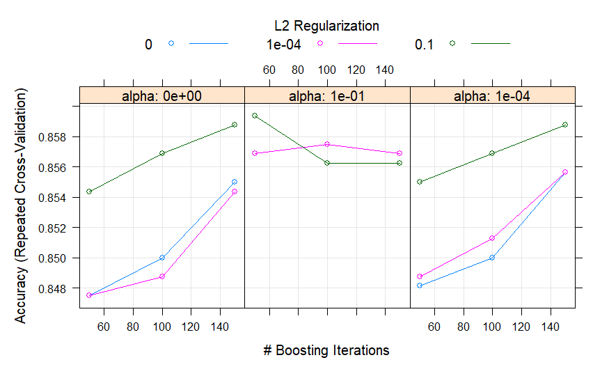

```r
plot(down_xgb_lin_clf)
```

Perform hyperparameter tuning using `tuneGrid`.

```r
down_xgb_lin_tuneGrid <- expand.grid(
  eta = 0.3,
  lambda = 0.1,
  alpha = c(0.0001, 0.001, 0.01, 0.1, 0),
  nrounds = seq(50, 200, 10)
)

down_xgb_lin_clf <- train_model(
  "xgbLinear",
  down_train_set,
  tuneGrid = down_xgb_lin_tuneGrid
)
```

```
eXtreme Gradient Boosting

160 samples
 32 predictor
  2 classes: 'fail', 'pass'

Pre-processing: centered (72), scaled (72)
Resampling: Cross-Validated (10 fold, repeated 10 times)
Summary of sample sizes: 144, 144, 144, 144, 144, 144, ...
Resampling results across tuning parameters:

  alpha  nrounds  Accuracy  Kappa
  0e+00   50      0.854375  0.70875
  0e+00   60      0.853750  0.70750
  0e+00   70      0.856250  0.71250
  0e+00   80      0.858125  0.71625
  0e+00   90      0.858125  0.71625
  0e+00  100      0.856875  0.71375
  0e+00  110      0.858125  0.71625
  0e+00  120      0.858750  0.71750
  0e+00  130      0.859375  0.71875
  0e+00  140      0.858750  0.71750
  0e+00  150      0.858750  0.71750
  0e+00  160      0.859375  0.71875
  0e+00  170      0.858750  0.71750
  0e+00  180      0.858125  0.71625
  0e+00  190      0.858125  0.71625
  0e+00  200      0.858125  0.71625
  1e-04   50      0.855000  0.71000
  1e-04   60      0.854375  0.70875
  1e-04   70      0.856250  0.71250
  1e-04   80      0.858125  0.71625
  1e-04   90      0.858750  0.71750
  1e-04  100      0.856875  0.71375
  1e-04  110      0.858750  0.71750
  1e-04  120      0.858750  0.71750
  1e-04  130      0.859375  0.71875
  1e-04  140      0.858750  0.71750
  1e-04  150      0.858750  0.71750
  1e-04  160      0.859375  0.71875
```

[output cut: 44 more lines]

```
  1e-01  130      0.856875  0.71375
  1e-01  140      0.856250  0.71250
  1e-01  150      0.856250  0.71250
  1e-01  160      0.855625  0.71125
  1e-01  170      0.855625  0.71125
  1e-01  180      0.855000  0.71000
  1e-01  190      0.855000  0.71000
  1e-01  200      0.855000  0.71000

Tuning parameter 'lambda' was held constant at a value of 0.1
Tuning parameter 'eta' was
 held constant at a value of 0.3
Accuracy was used to select the optimal model using the largest value.
The final values used for the model were nrounds = 80, lambda = 0.1, alpha = 0.01 and eta
 = 0.3.
```

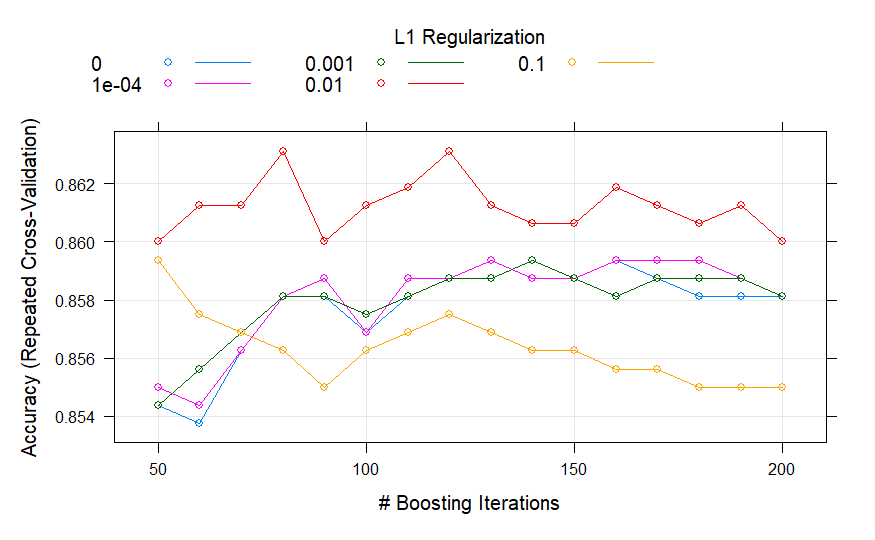

```r
plot(down_xgb_lin_clf)
```

Tuning done.

```r
down_xgb_lin_metrics <- evaluate_model(down_xgb_lin_clf, "XGB - Linear", "XGB")
```

```
Confusion Matrix and Statistics

          Reference
Prediction fail pass
      fail   15    9
      pass    5  100

               Accuracy : 0.8915
                 95% CI : (0.8246, 0.9394)
    No Information Rate : 0.845
    P-Value [Acc > NIR] : 0.08614

                  Kappa : 0.617

 Mcnemar's Test P-Value : 0.42268

              Precision : 0.6250
                 Recall : 0.7500
                     F1 : 0.6818
             Prevalence : 0.1550
         Detection Rate : 0.1163
   Detection Prevalence : 0.1860
      Balanced Accuracy : 0.8337

       'Positive' Class : fail
```

##### Up-Sampled Train Set

```r
up_xgb_lin_clf <- train_model("xgbLinear", up_train_set)
```

```
eXtreme Gradient Boosting

880 samples
 32 predictor
  2 classes: 'fail', 'pass'

Pre-processing: centered (72), scaled (72)
Resampling: Cross-Validated (10 fold, repeated 10 times)
Summary of sample sizes: 792, 792, 792, 792, 792, 792, ...
Resampling results across tuning parameters:

  lambda  alpha  nrounds  Accuracy   Kappa
  0e+00   0e+00   50      0.9759091  0.9518182
  0e+00   0e+00  100      0.9759091  0.9518182
  0e+00   0e+00  150      0.9762500  0.9525000
  0e+00   1e-04   50      0.9759091  0.9518182
  0e+00   1e-04  100      0.9759091  0.9518182
  0e+00   1e-04  150      0.9754545  0.9509091
  0e+00   1e-01   50      0.9754545  0.9509091
  0e+00   1e-01  100      0.9757955  0.9515909
  0e+00   1e-01  150      0.9756818  0.9513636
  1e-04   0e+00   50      0.9759091  0.9518182
  1e-04   0e+00  100      0.9760227  0.9520455
  1e-04   0e+00  150      0.9757955  0.9515909
  1e-04   1e-04   50      0.9761364  0.9522727
  1e-04   1e-04  100      0.9756818  0.9513636
  1e-04   1e-04  150      0.9755682  0.9511364
  1e-04   1e-01   50      0.9753409  0.9506818
  1e-04   1e-01  100      0.9756818  0.9513636
  1e-04   1e-01  150      0.9755682  0.9511364
  1e-01   0e+00   50      0.9764773  0.9529545
  1e-01   0e+00  100      0.9761364  0.9522727
  1e-01   0e+00  150      0.9757955  0.9515909
  1e-01   1e-04   50      0.9764773  0.9529545
  1e-01   1e-04  100      0.9761364  0.9522727
  1e-01   1e-04  150      0.9756818  0.9513636
  1e-01   1e-01   50      0.9777273  0.9554545
  1e-01   1e-01  100      0.9770455  0.9540909
  1e-01   1e-01  150      0.9764773  0.9529545

Tuning parameter 'eta' was held constant at a value of 0.3
Accuracy was used to select the optimal model using the largest value.
The final values used for the model were nrounds = 50, lambda = 0.1, alpha = 0.1 and eta = 0.3.
```

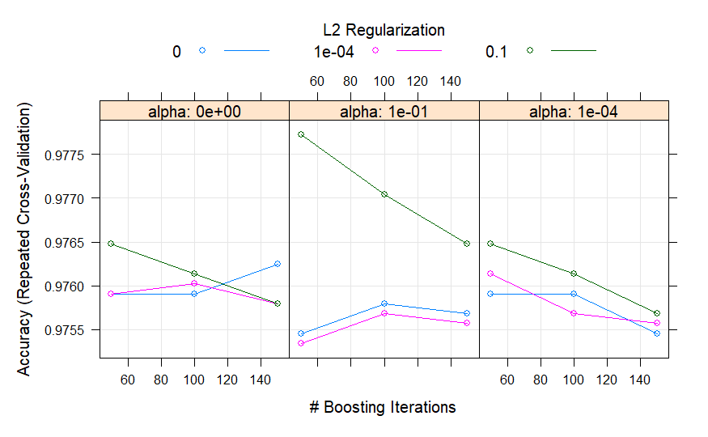

```r
plot(up_xgb_lin_clf)
```

No further tuning required.

```r
up_xgb_lin_metrics <- evaluate_model(up_xgb_lin_clf, "XGB - Linear", "XGB")
```

```
Confusion Matrix and Statistics

          Reference
Prediction fail pass
      fail   15    6
      pass    5  103

               Accuracy : 0.9147
                 95% CI : (0.8525, 0.9567)
    No Information Rate : 0.845
    P-Value [Acc > NIR] : 0.01442

                  Kappa : 0.6811

 Mcnemar's Test P-Value : 1.00000

              Precision : 0.7143
                 Recall : 0.7500
                     F1 : 0.7317
             Prevalence : 0.1550
         Detection Rate : 0.1163
   Detection Prevalence : 0.1628
      Balanced Accuracy : 0.8475

       'Positive' Class : fail
```

#### XGBoost (Tree)

Define a helper function to train XGBoost model with less verbose output.

```r
train_xgb_tree <- function(method = "",
                        data = train_set,
                        tuneGrid = NULL,
                        tuneLength = 3) {
  set.seed(42)

  fit <- train(
    result ~ .,
    data = data,
    method = method,
    trControl = fit_control,
    preProcess = c("center", "scale"),
    tuneGrid = tuneGrid,
    tuneLength = tuneLength,
    verbosity = 0
  )

  print(fit)

  return(fit)
}
```

##### Original Train Set

```r
xgb_tree_clf <- train_xgb_tree("xgbTree")
```

```
eXtreme Gradient Boosting

520 samples
 32 predictor
  2 classes: 'fail', 'pass'

Pre-processing: centered (72), scaled (72)
Resampling: Cross-Validated (10 fold, repeated 10 times)
Summary of sample sizes: 468, 468, 468, 468, 468, 468, ...
Resampling results across tuning parameters:

  eta  max_depth  colsample_bytree  subsample  nrounds  Accuracy   Kappa
  0.3  1          0.6               0.50        50      0.9321154  0.7302078
  0.3  1          0.6               0.50       100      0.9307692  0.7271489
  0.3  1          0.6               0.50       150      0.9286538  0.7196484
  0.3  1          0.6               0.75        50      0.9344231  0.7382702
  0.3  1          0.6               0.75       100      0.9342308  0.7394602
  0.3  1          0.6               0.75       150      0.9305769  0.7282059
  0.3  1          0.6               1.00        50      0.9307692  0.7199439
  0.3  1          0.6               1.00       100      0.9325000  0.7306540
  0.3  1          0.6               1.00       150      0.9350000  0.7438275
  0.3  1          0.8               0.50        50      0.9330769  0.7322149
  0.3  1          0.8               0.50       100      0.9321154  0.7344227
  0.3  1          0.8               0.50       150      0.9303846  0.7281943
  0.3  1          0.8               0.75        50      0.9307692  0.7225455
  0.3  1          0.8               0.75       100      0.9334615  0.7391234
  0.3  1          0.8               0.75       150      0.9317308  0.7311039
  0.3  1          0.8               1.00        50      0.9305769  0.7198202
  0.3  1          0.8               1.00       100      0.9340385  0.7369611
  0.3  1          0.8               1.00       150      0.9336538  0.7373204
  0.3  2          0.6               0.50        50      0.9313462  0.7271806
  0.3  2          0.6               0.50       100      0.9328846  0.7349835
  0.3  2          0.6               0.50       150      0.9332692  0.7378575
  0.3  2          0.6               0.75        50      0.9340385  0.7355346
  0.3  2          0.6               0.75       100      0.9351923  0.7430040
  0.3  2          0.6               0.75       150      0.9348077  0.7419379
  0.3  2          0.6               1.00        50      0.9307692  0.7228150
  0.3  2          0.6               1.00       100      0.9325000  0.7311761
  0.3  2          0.6               1.00       150      0.9330769  0.7345529
  0.3  2          0.8               0.50        50      0.9313462  0.7288871
```

[output cut: 72 more lines]

```
  0.4  3          0.8               0.50       100      0.9303846  0.7225685
  0.4  3          0.8               0.50       150      0.9276923  0.7130143
  0.4  3          0.8               0.75        50      0.9296154  0.7208187
  0.4  3          0.8               0.75       100      0.9275000  0.7141669
  0.4  3          0.8               0.75       150      0.9284615  0.7217233
  0.4  3          0.8               1.00        50      0.9326923  0.7328602
  0.4  3          0.8               1.00       100      0.9323077  0.7324098
  0.4  3          0.8               1.00       150      0.9332692  0.7391075

Tuning parameter 'gamma' was held constant at a value of 0
Tuning parameter
 'min_child_weight' was held constant at a value of 1
Accuracy was used to select the optimal model using the largest value.
The final values used for the model were nrounds = 150, max_depth = 1, eta = 0.4, gamma =
 0, colsample_bytree = 0.8, min_child_weight = 1 and subsample = 1.
```

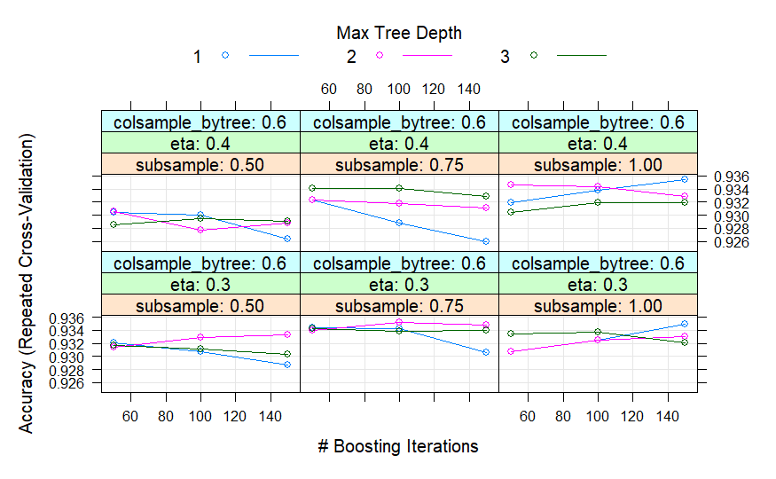

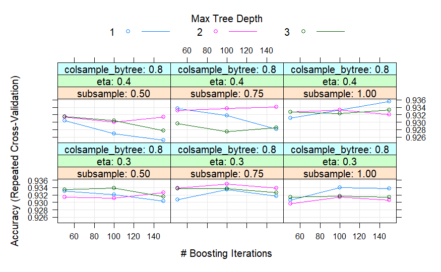

```r
plot(xgb_tree_clf)
```

Perform hyperparameter tuning using `tuneGrid`.

```r
xgb_tree_tuneGrid <- expand.grid(
  gamma = 0,
  min_child_weight = 1,
  max_depth = 1,
  eta = 0.4,
  subsample = 1,
  colsample_bytree = seq(0.6, 1.0, 0.1),
  nrounds = seq(100, 200, 10)
)

xgb_tree_clf <- train_xgb_tree("xgbTree", tuneGrid = xgb_tree_tuneGrid)
```

```
eXtreme Gradient Boosting

520 samples
 32 predictor
  2 classes: 'fail', 'pass'

Pre-processing: centered (72), scaled (72)
Resampling: Cross-Validated (10 fold, repeated 10 times)
Summary of sample sizes: 468, 468, 468, 468, 468, 468, ...
Resampling results across tuning parameters:

  colsample_bytree  nrounds  Accuracy   Kappa
  0.6               100      0.9332692  0.7347739
  0.6               110      0.9325000  0.7328846
  0.6               120      0.9332692  0.7362590
  0.6               130      0.9350000  0.7416292
  0.6               140      0.9344231  0.7402871
  0.6               150      0.9346154  0.7422851
  0.6               160      0.9355769  0.7448080
  0.6               170      0.9344231  0.7410688
  0.6               180      0.9342308  0.7398477
  0.6               190      0.9334615  0.7379368
  0.6               200      0.9332692  0.7360356
  0.7               100      0.9326923  0.7347074
  0.7               110      0.9338462  0.7404792
  0.7               120      0.9346154  0.7422016
  0.7               130      0.9351923  0.7447616
  0.7               140      0.9359615  0.7484730
  0.7               150      0.9357692  0.7469803
  0.7               160      0.9350000  0.7448234
  0.7               170      0.9350000  0.7453710
  0.7               180      0.9346154  0.7434019
  0.7               190      0.9348077  0.7439094
  0.7               200      0.9342308  0.7417275
  0.8               100      0.9340385  0.7398883
  0.8               110      0.9350000  0.7445829
  0.8               120      0.9357692  0.7456070
  0.8               130      0.9361538  0.7474203
  0.8               140      0.9369231  0.7515749
  0.8               150      0.9371154  0.7517649
```

[output cut: 22 more lines]

[output not shown]

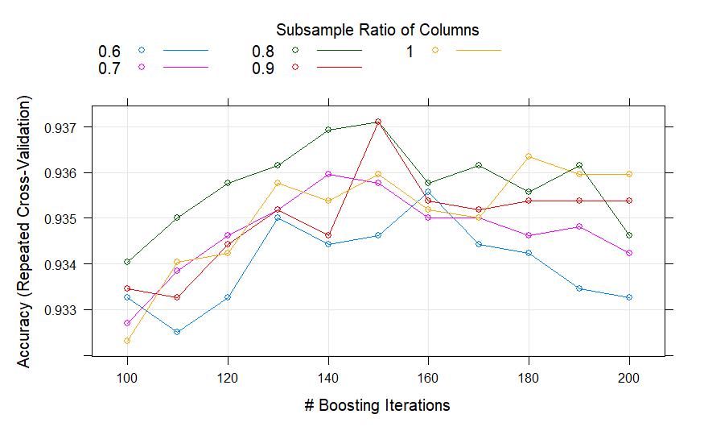

```r
plot(xgb_tree_clf)
```

Tuning done.

```r
xgb_tree_metrics <- evaluate_model(xgb_tree_clf, "XGB - Tree", "XGB")
```

```
Confusion Matrix and Statistics

          Reference
Prediction fail pass
      fail   15    5
      pass    5  104

               Accuracy : 0.9225
                 95% CI : (0.8621, 0.9622)
    No Information Rate : 0.845
    P-Value [Acc > NIR] : 0.006716

                  Kappa : 0.7041

 Mcnemar's Test P-Value : 1.000000

              Precision : 0.7500
                 Recall : 0.7500
                     F1 : 0.7500
             Prevalence : 0.1550
         Detection Rate : 0.1163
   Detection Prevalence : 0.1550
      Balanced Accuracy : 0.8521

       'Positive' Class : fail
```

##### Down-Sampled Train Set

```r
down_xgb_tree_clf <- train_xgb_tree("xgbTree", down_train_set)
```

```
eXtreme Gradient Boosting

160 samples
 32 predictor
  2 classes: 'fail', 'pass'

Pre-processing: centered (72), scaled (72)
Resampling: Cross-Validated (10 fold, repeated 10 times)
Summary of sample sizes: 144, 144, 144, 144, 144, 144, ...
Resampling results across tuning parameters:

  eta  max_depth  colsample_bytree  subsample  nrounds  Accuracy  Kappa
  0.3  1          0.6               0.50        50      0.863750  0.72750
  0.3  1          0.6               0.50       100      0.858125  0.71625
  0.3  1          0.6               0.50       150      0.850625  0.70125
  0.3  1          0.6               0.75        50      0.848125  0.69625
  0.3  1          0.6               0.75       100      0.850000  0.70000
  0.3  1          0.6               0.75       150      0.843125  0.68625
  0.3  1          0.6               1.00        50      0.849375  0.69875
  0.3  1          0.6               1.00       100      0.845000  0.69000
  0.3  1          0.6               1.00       150      0.833125  0.66625
  0.3  1          0.8               0.50        50      0.853750  0.70750
  0.3  1          0.8               0.50       100      0.851250  0.70250
  0.3  1          0.8               0.50       150      0.844375  0.68875
  0.3  1          0.8               0.75        50      0.861250  0.72250
  0.3  1          0.8               0.75       100      0.846250  0.69250
  0.3  1          0.8               0.75       150      0.838125  0.67625
  0.3  1          0.8               1.00        50      0.853125  0.70625
  0.3  1          0.8               1.00       100      0.840000  0.68000
  0.3  1          0.8               1.00       150      0.831875  0.66375
  0.3  2          0.6               0.50        50      0.858750  0.71750
  0.3  2          0.6               0.50       100      0.850625  0.70125
  0.3  2          0.6               0.50       150      0.849375  0.69875
  0.3  2          0.6               0.75        50      0.856250  0.71250
  0.3  2          0.6               0.75       100      0.852500  0.70500
  0.3  2          0.6               0.75       150      0.847500  0.69500
  0.3  2          0.6               1.00        50      0.841875  0.68375
  0.3  2          0.6               1.00       100      0.840000  0.68000
  0.3  2          0.6               1.00       150      0.842500  0.68500
  0.3  2          0.8               0.50        50      0.855625  0.71125
```

[output cut: 72 more lines]

```
  0.4  3          0.8               0.50       100      0.848750  0.69750
  0.4  3          0.8               0.50       150      0.840625  0.68125
  0.4  3          0.8               0.75        50      0.851875  0.70375
  0.4  3          0.8               0.75       100      0.853125  0.70625
  0.4  3          0.8               0.75       150      0.847500  0.69500
  0.4  3          0.8               1.00        50      0.860000  0.72000
  0.4  3          0.8               1.00       100      0.855000  0.71000
  0.4  3          0.8               1.00       150      0.853750  0.70750

Tuning parameter 'gamma' was held constant at a value of 0
Tuning parameter
 'min_child_weight' was held constant at a value of 1
Accuracy was used to select the optimal model using the largest value.
The final values used for the model were nrounds = 50, max_depth = 3, eta = 0.3, gamma =
 0, colsample_bytree = 0.6, min_child_weight = 1 and subsample = 0.5.
```

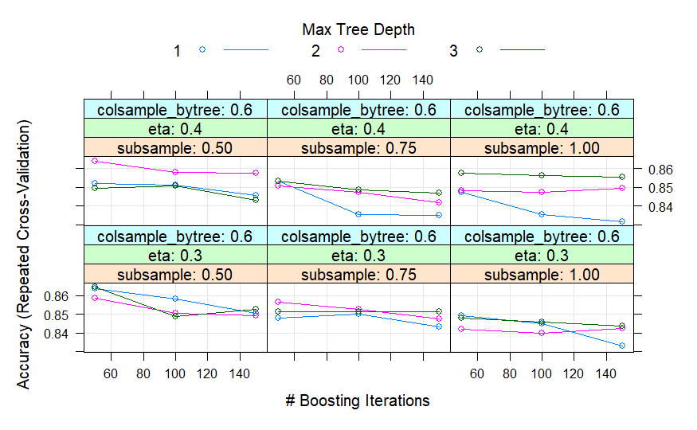

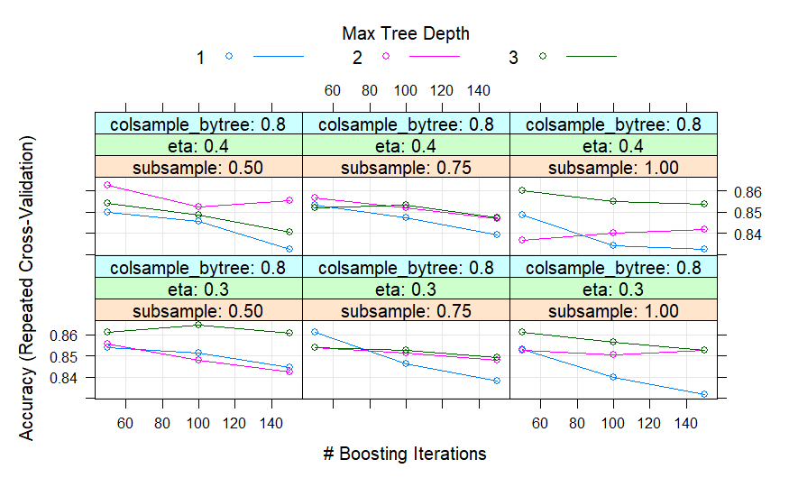

```r
plot(down_xgb_tree_clf)
```

No further tuning required.

```r
down_xgb_tree_metrics <- evaluate_model(down_xgb_tree_clf, "XGB - Tree", "XGB")
```

```
Confusion Matrix and Statistics

          Reference
Prediction fail pass
      fail   16    9
      pass    4  100

               Accuracy : 0.8992
                 95% CI : (0.8338, 0.9452)
    No Information Rate : 0.845
    P-Value [Acc > NIR] : 0.05125

                  Kappa : 0.651

 Mcnemar's Test P-Value : 0.26726

              Precision : 0.6400
                 Recall : 0.8000
                     F1 : 0.7111
             Prevalence : 0.1550
         Detection Rate : 0.1240
   Detection Prevalence : 0.1938
      Balanced Accuracy : 0.8587

       'Positive' Class : fail
```

##### Up-Sampled Train Set

```r
up_xgb_tree_clf <- train_xgb_tree("xgbTree", up_train_set)
```

```
eXtreme Gradient Boosting

880 samples
 32 predictor
  2 classes: 'fail', 'pass'

Pre-processing: centered (72), scaled (72)
Resampling: Cross-Validated (10 fold, repeated 10 times)
Summary of sample sizes: 792, 792, 792, 792, 792, 792, ...
Resampling results across tuning parameters:

  eta  max_depth  colsample_bytree  subsample  nrounds  Accuracy   Kappa
  0.3  1          0.6               0.50        50      0.9357955  0.8715909
  0.3  1          0.6               0.50       100      0.9403409  0.8806818
  0.3  1          0.6               0.50       150      0.9452273  0.8904545
  0.3  1          0.6               0.75        50      0.9347727  0.8695455
  0.3  1          0.6               0.75       100      0.9396591  0.8793182
  0.3  1          0.6               0.75       150      0.9440909  0.8881818
  0.3  1          0.6               1.00        50      0.9355682  0.8711364
  0.3  1          0.6               1.00       100      0.9413636  0.8827273
  0.3  1          0.6               1.00       150      0.9432955  0.8865909
  0.3  1          0.8               0.50        50      0.9327273  0.8654545
  0.3  1          0.8               0.50       100      0.9412500  0.8825000
  0.3  1          0.8               0.50       150      0.9457955  0.8915909
  0.3  1          0.8               0.75        50      0.9368182  0.8736364
  0.3  1          0.8               0.75       100      0.9414773  0.8829545
  0.3  1          0.8               0.75       150      0.9471591  0.8943182
  0.3  1          0.8               1.00        50      0.9331818  0.8663636
  0.3  1          0.8               1.00       100      0.9393182  0.8786364
  0.3  1          0.8               1.00       150      0.9428409  0.8856818
  0.3  2          0.6               0.50        50      0.9646591  0.9293182
  0.3  2          0.6               0.50       100      0.9719318  0.9438636
  0.3  2          0.6               0.50       150      0.9745455  0.9490909
  0.3  2          0.6               0.75        50      0.9675000  0.9350000
  0.3  2          0.6               0.75       100      0.9725000  0.9450000
  0.3  2          0.6               0.75       150      0.9743182  0.9486364
  0.3  2          0.6               1.00        50      0.9686364  0.9372727
  0.3  2          0.6               1.00       100      0.9731818  0.9463636
  0.3  2          0.6               1.00       150      0.9746591  0.9493182
  0.3  2          0.8               0.50        50      0.9678409  0.9356818
```

[output cut: 72 more lines]

```
  0.4  3          0.8               0.50       100      0.9729545  0.9459091
  0.4  3          0.8               0.50       150      0.9730682  0.9461364
  0.4  3          0.8               0.75        50      0.9739773  0.9479545
  0.4  3          0.8               0.75       100      0.9750000  0.9500000
  0.4  3          0.8               0.75       150      0.9755682  0.9511364
  0.4  3          0.8               1.00        50      0.9734091  0.9468182
  0.4  3          0.8               1.00       100      0.9743182  0.9486364
  0.4  3          0.8               1.00       150      0.9739773  0.9479545

Tuning parameter 'gamma' was held constant at a value of 0
Tuning parameter
 'min_child_weight' was held constant at a value of 1
Accuracy was used to select the optimal model using the largest value.
The final values used for the model were nrounds = 150, max_depth = 2, eta = 0.4, gamma =
 0, colsample_bytree = 0.6, min_child_weight = 1 and subsample = 1.
```

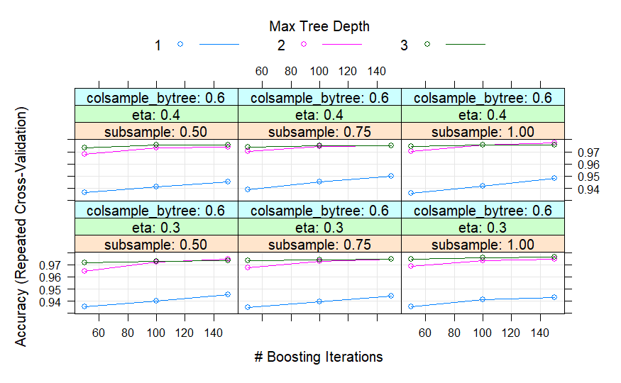

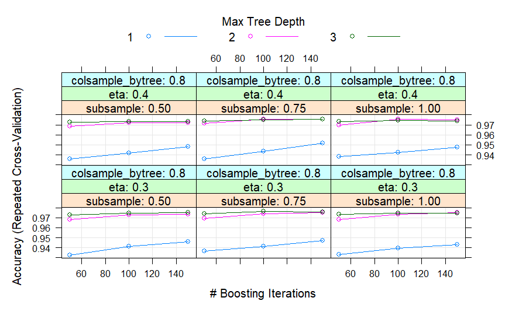

```r
plot(up_xgb_tree_clf)
```

Perform hyperparameter tuning using `tuneGrid`.

```r
up_xgb_tree_tuneGrid <- expand.grid(
  gamma = 0,
  min_child_weight = 1,
  max_depth = 2,
  eta = 0.4,
  subsample = 1,
  colsample_bytree = 0.6,
  nrounds = seq(100, 200, 10)
)

up_xgb_tree_clf <- train_xgb_tree(
  "xgbTree",
  up_train_set,
  tuneGrid = up_xgb_tree_tuneGrid
)
```

[output not shown]

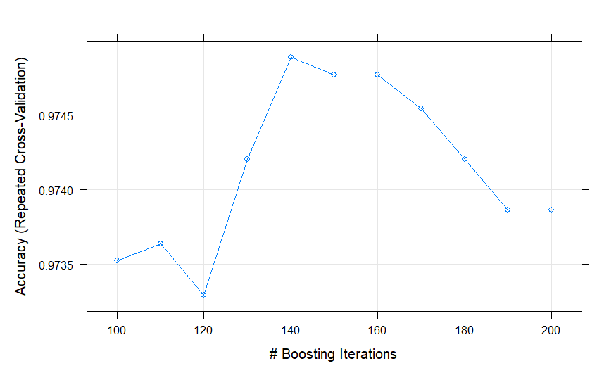

```r
plot(up_xgb_tree_clf)
```

Tuning done.

```r
up_xgb_tree_metrics <- evaluate_model(up_xgb_tree_clf, "XGB - Tree", "XGB")
```

```
Confusion Matrix and Statistics

          Reference
Prediction fail pass
      fail   13    6
      pass    7  103

               Accuracy : 0.8992
                 95% CI : (0.8338, 0.9452)
    No Information Rate : 0.845
    P-Value [Acc > NIR] : 0.05125

                  Kappa : 0.6074

 Mcnemar's Test P-Value : 1.00000

              Precision : 0.6842
                 Recall : 0.6500
                     F1 : 0.6667
             Prevalence : 0.1550
         Detection Rate : 0.1008
   Detection Prevalence : 0.1473
      Balanced Accuracy : 0.7975

       'Positive' Class : fail
```

#### Neural Network

Define a helper function to train neural network model with less verbose output.

```r
train_nn <- function(method = "",
                        data = train_set,
                        tuneGrid = NULL,
                        tuneLength = 3) {
  set.seed(42)

  fit <- train(
    result ~ .,
    data = data,
    method = method,
    trControl = fit_control,
    preProcess = c("center", "scale"),
    tuneGrid = tuneGrid,
    tuneLength = tuneLength,
    trace = FALSE
  )

  print(fit)

  return(fit)
}
```

##### Original Train Set

```r
nn_clf <- train_nn("nnet")
```

```
Neural Network

520 samples
 32 predictor
  2 classes: 'fail', 'pass'

Pre-processing: centered (72), scaled (72)
Resampling: Cross-Validated (10 fold, repeated 10 times)
Summary of sample sizes: 468, 468, 468, 468, 468, 468, ...
Resampling results across tuning parameters:

  size  decay  Accuracy   Kappa
  1     0e+00  0.8465385  0.5173854
  1     1e-04  0.8484615  0.5252703
  1     1e-01  0.8851923  0.5825296
  3     0e+00  0.8713462  0.5135806
  3     1e-04  0.8673077  0.5023660
  3     1e-01  0.8909615  0.5792622
  5     0e+00  0.8669231  0.4964791
  5     1e-04  0.8711538  0.5090712
  5     1e-01  0.8973077  0.6047691

Accuracy was used to select the optimal model using the largest value.
The final values used for the model were size = 5 and decay = 0.1.
```

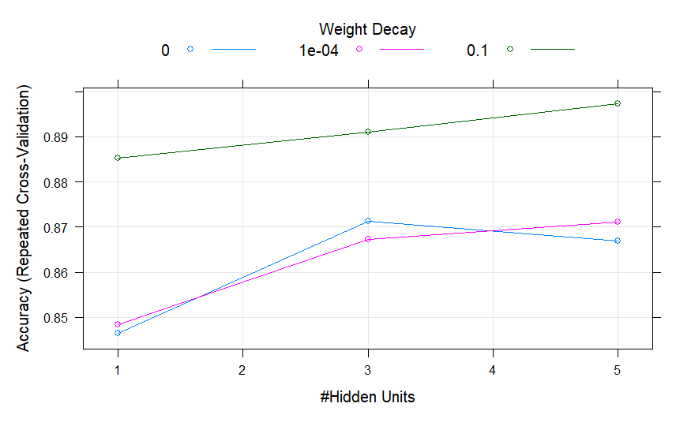

```r
plot(nn_clf)
```

Perform hyperparameter tuning using `tuneLength`.

```r
nn_clf <- train_nn("nnet", tuneLength = 7)
```

```
Neural Network

520 samples
 32 predictor
  2 classes: 'fail', 'pass'

Pre-processing: centered (72), scaled (72)
Resampling: Cross-Validated (10 fold, repeated 10 times)
Summary of sample sizes: 468, 468, 468, 468, 468, 468, ...
Resampling results across tuning parameters:

  size  decay         Accuracy   Kappa
   1    0.0000000000  0.8438462  0.5158654
   1    0.0001000000  0.8542308  0.5431513
   1    0.0003981072  0.8530769  0.5352498
```

[output cut: 49 more lines]

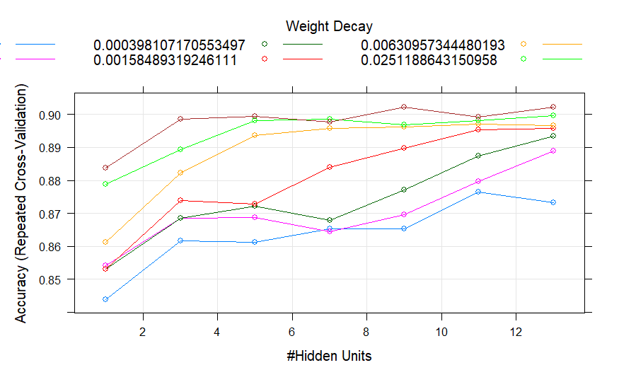

```r
plot(nn_clf)
```

Tuning done.

```r
nn_metrics <- evaluate_model(nn_clf, "NN")
```

```
Confusion Matrix and Statistics

          Reference
Prediction fail pass
      fail   13    5
      pass    7  104

               Accuracy : 0.907
                 95% CI : (0.8431, 0.951)
    No Information Rate : 0.845
    P-Value [Acc > NIR] : 0.02831

                  Kappa : 0.6298

 Mcnemar's Test P-Value : 0.77283

              Precision : 0.7222
                 Recall : 0.6500
                     F1 : 0.6842
             Prevalence : 0.1550
         Detection Rate : 0.1008
   Detection Prevalence : 0.1395
      Balanced Accuracy : 0.8021

       'Positive' Class : fail
```

##### Down-Sampled Train Set

```r
down_nn_clf <- train_nn("nnet", down_train_set)
```

```
Neural Network

160 samples
 32 predictor
  2 classes: 'fail', 'pass'

Pre-processing: centered (72), scaled (72)
Resampling: Cross-Validated (10 fold, repeated 10 times)
Summary of sample sizes: 144, 144, 144, 144, 144, 144, ...
Resampling results across tuning parameters:

  size  decay  Accuracy  Kappa
  1     0e+00  0.761250  0.52250
  1     1e-04  0.763750  0.52750
  1     1e-01  0.771250  0.54250
  3     0e+00  0.768125  0.53625
  3     1e-04  0.776250  0.55250
  3     1e-01  0.782500  0.56500
  5     0e+00  0.753750  0.50750
  5     1e-04  0.761875  0.52375
  5     1e-01  0.776250  0.55250

Accuracy was used to select the optimal model using the largest value.
The final values used for the model were size = 3 and decay = 0.1.
```

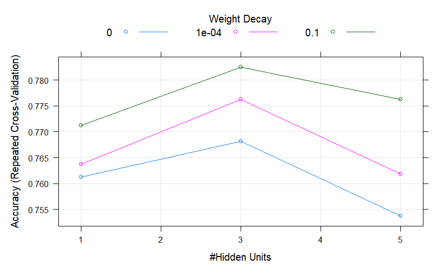

```r
plot(down_nn_clf)
```

Perform hyperparameter tuning with `tuneLength`.

```r
down_nn_clf <- train_nn("nnet", down_train_set, tuneLength = 7)
```

```
Neural Network

160 samples
 32 predictor
  2 classes: 'fail', 'pass'

Pre-processing: centered (72), scaled (72)
Resampling: Cross-Validated (10 fold, repeated 10 times)
Summary of sample sizes: 144, 144, 144, 144, 144, 144, ...
Resampling results across tuning parameters:

  size  decay         Accuracy  Kappa
   1    0.0000000000  0.768750  0.53750
   1    0.0001000000  0.755000  0.51000
   1    0.0003981072  0.765625  0.53125
```

[output cut: 49 more lines]

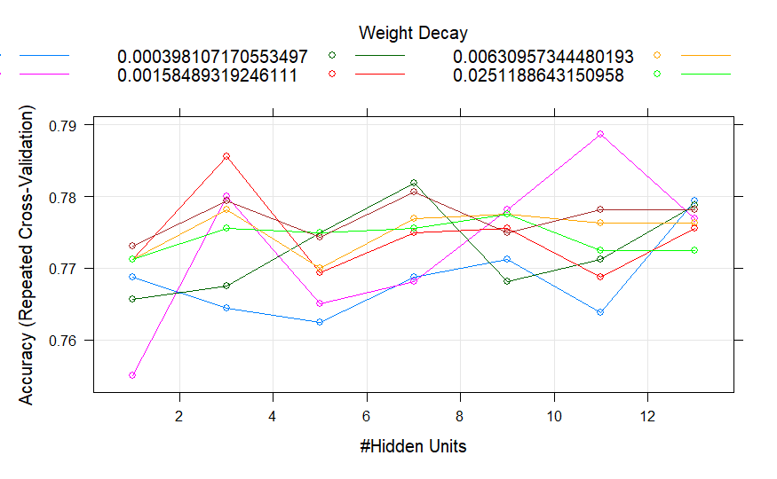

```r
plot(down_nn_clf)
```

Tuning done.

```r
down_nn_metrics <- evaluate_model(down_nn_clf, "NN")
```

```
Confusion Matrix and Statistics

          Reference
Prediction fail pass
      fail   14   15
      pass    6   94

               Accuracy : 0.8372
                 95% CI : (0.762, 0.8963)
    No Information Rate : 0.845
    P-Value [Acc > NIR] : 0.65133

                  Kappa : 0.4751

 Mcnemar's Test P-Value : 0.08086

              Precision : 0.4828
                 Recall : 0.7000
                     F1 : 0.5714
             Prevalence : 0.1550
         Detection Rate : 0.1085
   Detection Prevalence : 0.2248
      Balanced Accuracy : 0.7812

       'Positive' Class : fail
```

##### Up-Sampled Train Set

```r
up_nn_clf <- train_nn("nnet", up_train_set)
```

```
Neural Network

880 samples
 32 predictor
  2 classes: 'fail', 'pass'

Pre-processing: centered (72), scaled (72)
Resampling: Cross-Validated (10 fold, repeated 10 times)
Summary of sample sizes: 792, 792, 792, 792, 792, 792, ...
Resampling results across tuning parameters:

  size  decay  Accuracy   Kappa
  1     0e+00  0.9244318  0.8488636
  1     1e-04  0.9325000  0.8650000
  1     1e-01  0.9450000  0.8900000
  3     0e+00  0.9460227  0.8920455
  3     1e-04  0.9448864  0.8897727
  3     1e-01  0.9588636  0.9177273
  5     0e+00  0.9537500  0.9075000
  5     1e-04  0.9552273  0.9104545
  5     1e-01  0.9610227  0.9220455

Accuracy was used to select the optimal model using the largest value.
The final values used for the model were size = 5 and decay = 0.1.
```

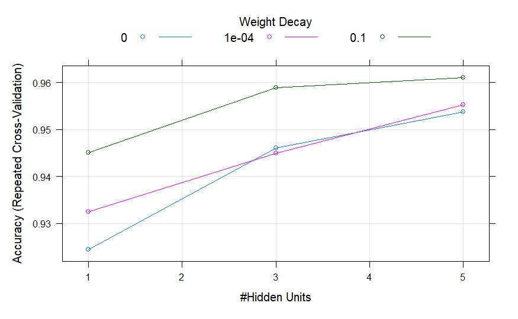

```r
plot(up_nn_clf)
```

Perform hyperparameter tuning with `tuneLength`.

```r
up_nn_clf <- train_nn("nnet", up_train_set, tuneLength = 7)
```

```
Neural Network

880 samples
 32 predictor
  2 classes: 'fail', 'pass'

Pre-processing: centered (72), scaled (72)
Resampling: Cross-Validated (10 fold, repeated 10 times)
Summary of sample sizes: 792, 792, 792, 792, 792, 792, ...
Resampling results across tuning parameters:

  size  decay         Accuracy   Kappa
   1    0.0000000000  0.9273864  0.8547727
   1    0.0001000000  0.9275000  0.8550000
   1    0.0003981072  0.9275000  0.8550000
```

[output cut: 49 more lines]

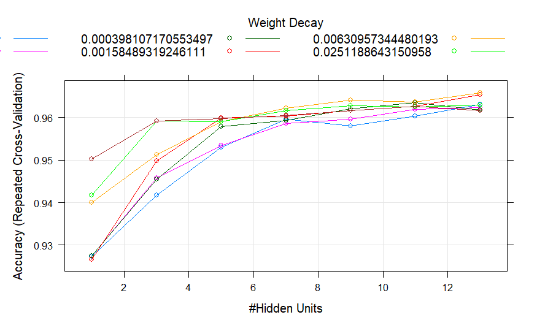

```r
plot(up_nn_clf)
```

Tuning done.

```r
up_nn_metrics <- evaluate_model(up_nn_clf, "NN")
```

```
Confusion Matrix and Statistics

          Reference
Prediction fail pass
      fail   15    7
      pass    5  102

               Accuracy : 0.907
                 95% CI : (0.8431, 0.951)
    No Information Rate : 0.845
    P-Value [Acc > NIR] : 0.02831

                  Kappa : 0.6589

 Mcnemar's Test P-Value : 0.77283

              Precision : 0.6818
                 Recall : 0.7500
                     F1 : 0.7143
             Prevalence : 0.1550
         Detection Rate : 0.1163
   Detection Prevalence : 0.1705
      Balanced Accuracy : 0.8429

       'Positive' Class : fail
```

### Evaluation

Define a function to aggregate accuracy from model of same family.

```r
aggregate_accuracy <- function(df) {
  df_accuracy <- df %>%
    group_by(Family) %>%
    slice(which.max(Accuracy)) %>%
    arrange(desc(Accuracy)) %>%
    select(-1)

  print(df_accuracy)

  plot_accuracy <- df_accuracy %>%
    ggplot(aes(x = reorder(Family, -Accuracy), y = Accuracy, fill = Family)) +
    geom_bar(stat = "identity") +
    geom_text(aes(label = Accuracy), vjust=-0.5) +
    ggtitle("Accuracy by Model") +
    xlab("Model") +
    ylim(0, 1) +
    labs(fill = "Model") +
    theme(axis.text.x = element_text(angle = 90, vjust = 0.5, hjust=1))

  print(plot_accuracy)
}
```

Define a function to aggregate F1 score from model of same family.

```r
aggregate_f1 <- function(df) {
  df_f1 <- df %>%
    group_by(Family) %>%
    slice(which.max(F1)) %>%
    arrange(desc(F1)) %>%
    select(-1)

  print(df_f1)

  plot_f1 <- df_f1 %>%
    ggplot(aes(x = reorder(Family, -F1), y = F1, fill = Family)) +
    geom_bar(stat = "identity") +
    geom_text(aes(label = F1), vjust=-0.5) +
    ggtitle("F1 Score by Model") +
    xlab("Model") +
    ylab("F1 Score") +
    ylim(0, 1) +
    labs(fill = "Model") +
    theme(axis.text.x = element_text(angle = 90, vjust = 0.5, hjust=1))

  print(plot_f1)
}
```

#### Original Train Set

```r
df_eval <- rbind(
  dt_metrics,
  rf_metrics,
  svm_lin_metrics,
  svm_poly_metrics,
  svm_rbf_metrics,
  nb_metrics,
  ab_metrics,
  xgb_lin_metrics,
  xgb_tree_metrics,
  nn_metrics
)

df_eval
```

| Model | Family | Accuracy | Precision | Recall | F1 |
| --- | --- | --- | --- | --- | --- |
| DT | DT | 0.938 | 0.929 | 0.65 | 0.765 |
| RF | RF | 0.922 | 0.778 | 0.70 | 0.737 |
| SVM - Linear | SVM | 0.907 | 0.700 | 0.70 | 0.700 |
| SVM - Poly | SVM | 0.915 | 0.737 | 0.70 | 0.718 |
| SVM - RBF | SVM | 0.891 | 0.688 | 0.55 | 0.611 |
| NB | NB | 0.837 | 0.486 | 0.85 | 0.618 |
| AB | AB | 0.922 | 0.812 | 0.65 | 0.722 |
| XGB - Linear | XGB | 0.915 | 0.737 | 0.70 | 0.718 |
| XGB - Tree | XGB | 0.922 | 0.750 | 0.75 | 0.750 |
| NN | NN | 0.907 | 0.722 | 0.65 | 0.684 |

##### By Accuracy

| Family | Accuracy | Precision | Recall | F1 |
| --- | --- | --- | --- | --- |
| DT | 0.938 | 0.929 | 0.65 | 0.765 |
| AB | 0.922 | 0.812 | 0.65 | 0.722 |
| RF | 0.922 | 0.778 | 0.70 | 0.737 |
| XGB | 0.922 | 0.750 | 0.75 | 0.750 |
| SVM | 0.915 | 0.737 | 0.70 | 0.718 |
| NN | 0.907 | 0.722 | 0.65 | 0.684 |
| NB | 0.837 | 0.486 | 0.85 | 0.618 |

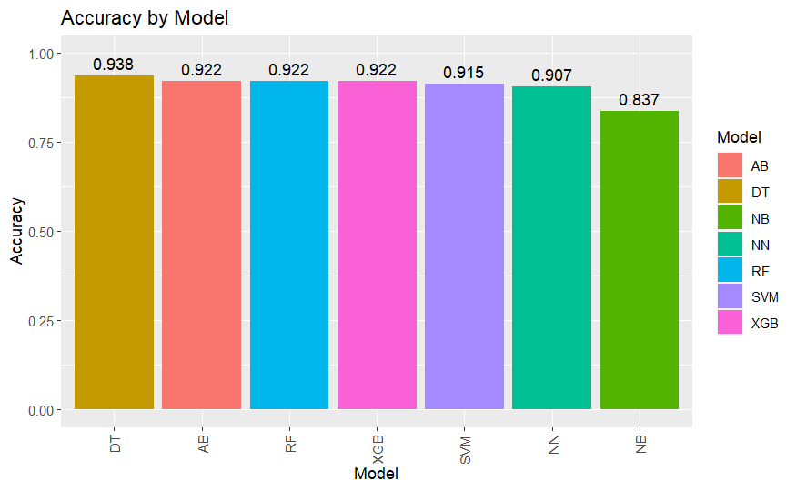

```r
aggregate_accuracy(df_eval)
```

##### By F1 Score

| Family | Accuracy | Precision | Recall | F1 |
| --- | --- | --- | --- | --- |
| DT | 0.938 | 0.929 | 0.65 | 0.765 |
| XGB | 0.922 | 0.750 | 0.75 | 0.750 |
| RF | 0.922 | 0.778 | 0.70 | 0.737 |
| AB | 0.922 | 0.812 | 0.65 | 0.722 |
| SVM | 0.915 | 0.737 | 0.70 | 0.718 |
| NN | 0.907 | 0.722 | 0.65 | 0.684 |
| NB | 0.837 | 0.486 | 0.85 | 0.618 |

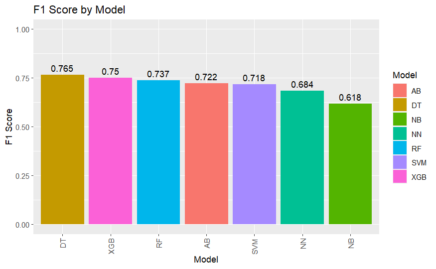

```r
aggregate_f1(df_eval)
```

#### Down-Sampled Train Set

```r
down_df_eval <- rbind(
  down_dt_metrics,
  down_rf_metrics,
  down_svm_lin_metrics,
  down_svm_poly_metrics,
  down_svm_rbf_metrics,
  down_nb_metrics,
  down_ab_metrics,
  down_xgb_lin_metrics,
  down_xgb_tree_metrics,
  down_nn_metrics
)

down_df_eval
```

| Model | Family | Accuracy | Precision | Recall | F1 |
| --- | --- | --- | --- | --- | --- |
| DT | DT | 0.860 | 0.531 | 0.85 | 0.654 |
| RF | RF | 0.876 | 0.567 | 0.85 | 0.680 |
| SVM - Linear | SVM | 0.853 | 0.515 | 0.85 | 0.642 |
| SVM - Poly | SVM | 0.860 | 0.529 | 0.90 | 0.667 |
| SVM - RBF | SVM | 0.860 | 0.529 | 0.90 | 0.667 |
| NB | NB | 0.822 | 0.459 | 0.85 | 0.596 |
| AB | AB | 0.891 | 0.607 | 0.85 | 0.708 |
| XGB - Linear | XGB | 0.891 | 0.625 | 0.75 | 0.682 |
| XGB - Tree | XGB | 0.899 | 0.640 | 0.80 | 0.711 |
| NN | NN | 0.837 | 0.483 | 0.70 | 0.571 |

##### By Accuracy

| Family | Accuracy | Precision | Recall | F1 |
| --- | --- | --- | --- | --- |
| XGB | 0.899 | 0.640 | 0.80 | 0.711 |
| AB | 0.891 | 0.607 | 0.85 | 0.708 |
| RF | 0.876 | 0.567 | 0.85 | 0.680 |
| DT | 0.860 | 0.531 | 0.85 | 0.654 |
| SVM | 0.860 | 0.529 | 0.90 | 0.667 |
| NN | 0.837 | 0.483 | 0.70 | 0.571 |
| NB | 0.822 | 0.459 | 0.85 | 0.596 |

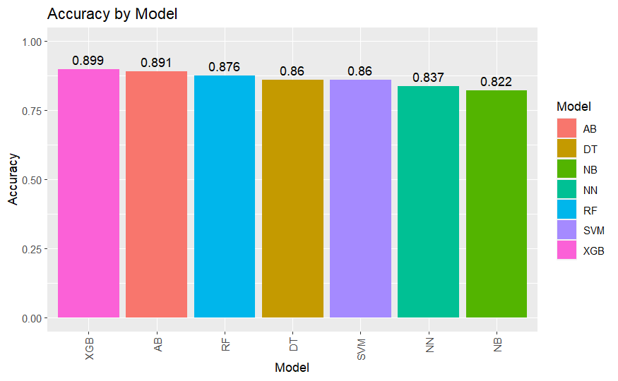

```r
aggregate_accuracy(down_df_eval)
```

##### By F1 Score

| Family | Accuracy | Precision | Recall | F1 |
| --- | --- | --- | --- | --- |
| XGB | 0.899 | 0.640 | 0.80 | 0.711 |
| AB | 0.891 | 0.607 | 0.85 | 0.708 |
| RF | 0.876 | 0.567 | 0.85 | 0.680 |
| SVM | 0.860 | 0.529 | 0.90 | 0.667 |
| DT | 0.860 | 0.531 | 0.85 | 0.654 |
| NB | 0.822 | 0.459 | 0.85 | 0.596 |
| NN | 0.837 | 0.483 | 0.70 | 0.571 |

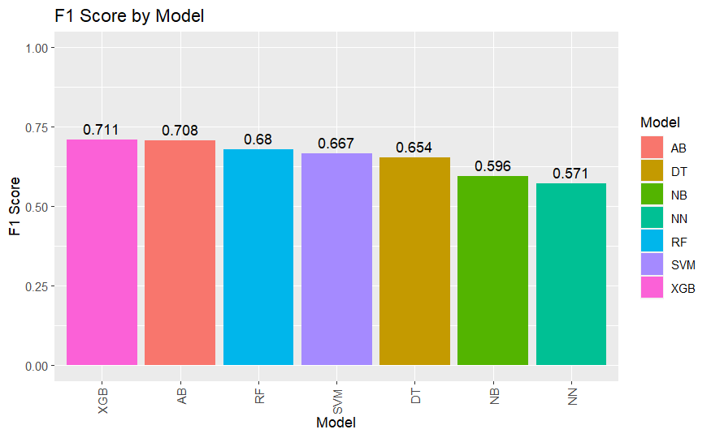

```r
aggregate_f1(down_df_eval)
```

#### Up-Sampled Train Set

```r
up_df_eval <- rbind(
  up_dt_metrics,
  up_rf_metrics,
  up_svm_lin_metrics,
  up_svm_poly_metrics,
  up_svm_rbf_metrics,
  up_nb_metrics,
  up_ab_metrics,
  up_xgb_lin_metrics,
  up_xgb_tree_metrics,
  up_nn_metrics
)

up_df_eval
```

| Model | Family | Accuracy | Precision | Recall | F1 |
| --- | --- | --- | --- | --- | --- |
| DT | DT | 0.884 | 0.593 | 0.80 | 0.681 |
| RF | RF | 0.915 | 0.800 | 0.60 | 0.686 |
| SVM - Linear | SVM | 0.899 | 0.684 | 0.65 | 0.667 |
| SVM - Poly | SVM | 0.891 | 0.875 | 0.35 | 0.500 |
| SVM - RBF | SVM | 0.899 | 0.706 | 0.60 | 0.649 |
| NB | NB | 0.806 | 0.432 | 0.80 | 0.561 |
| AB | AB | 0.915 | 0.765 | 0.65 | 0.703 |
| XGB - Linear | XGB | 0.915 | 0.714 | 0.75 | 0.732 |
| XGB - Tree | XGB | 0.899 | 0.684 | 0.65 | 0.667 |
| NN | NN | 0.907 | 0.682 | 0.75 | 0.714 |

##### By Accuracy

| Family | Accuracy | Precision | Recall | F1 |
| --- | --- | --- | --- | --- |
| AB | 0.915 | 0.765 | 0.65 | 0.703 |
| RF | 0.915 | 0.800 | 0.60 | 0.686 |
| XGB | 0.915 | 0.714 | 0.75 | 0.732 |
| NN | 0.907 | 0.682 | 0.75 | 0.714 |
| SVM | 0.899 | 0.684 | 0.65 | 0.667 |
| DT | 0.884 | 0.593 | 0.80 | 0.681 |
| NB | 0.806 | 0.432 | 0.80 | 0.561 |

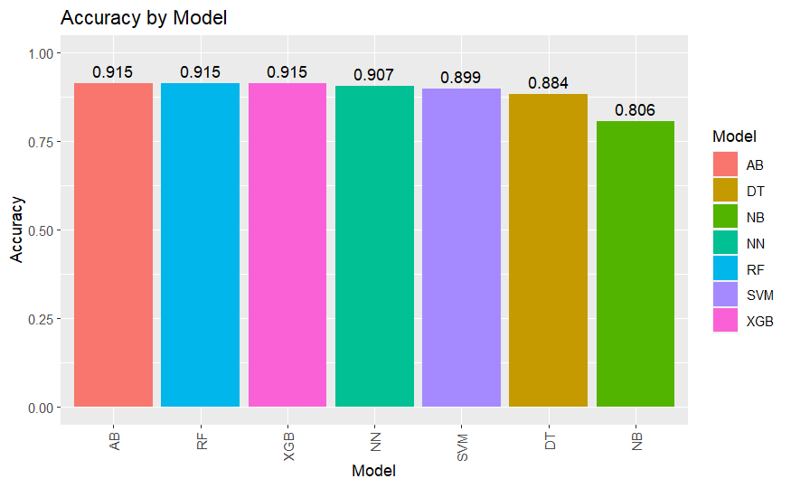

```r
aggregate_accuracy(up_df_eval)
```

##### By F1 Score

| Family | Accuracy | Precision | Recall | F1 |
| --- | --- | --- | --- | --- |
| XGB | 0.915 | 0.714 | 0.75 | 0.732 |
| NN | 0.907 | 0.682 | 0.75 | 0.714 |
| AB | 0.915 | 0.765 | 0.65 | 0.703 |
| RF | 0.915 | 0.800 | 0.60 | 0.686 |
| DT | 0.884 | 0.593 | 0.80 | 0.681 |
| SVM | 0.899 | 0.684 | 0.65 | 0.667 |
| NB | 0.806 | 0.432 | 0.80 | 0.561 |

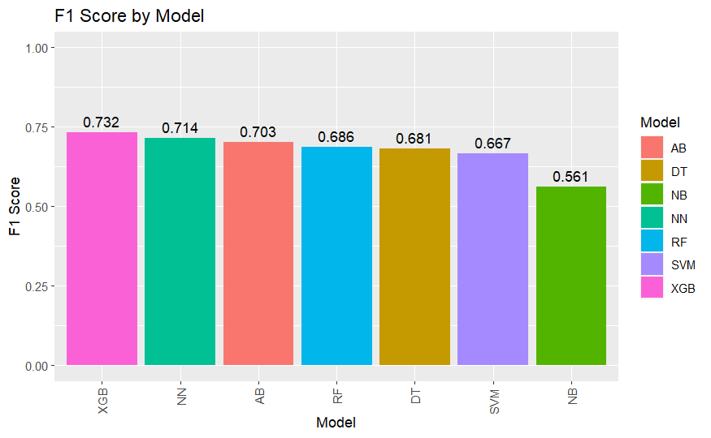

```r
aggregate_f1(up_df_eval)
```